# JOINING DATA WITH DPLYR: LEFT JOINS AND RIGHT JOINS

Load the Dplyr package and read the tables:

```r
library(dplyr)
inventories <- readRDS("inventories.rds")
inventory_parts <- readRDS("inventory_parts.rds")
```

Combine **inventories** and **inventory_parts** using `inner_join`:

```r
inventory_parts_joined <- inventories %>%
  inner_join(inventory_parts, by = c("id" = "inventory_id"))
```

For simplicity, remove the `id` and `version` variables since we don’t need them. Arrange to sort in order of quantity, which represents how many of a piece appear in each set:

```r
inventory_parts_joined <- inventory_parts_joined %>%
  select(-id, -version) %>%
  arrange(desc(quantity))
inventory_parts_joined
```

```
## # A tibble: 258,958 x 4
##    set_num  part_num color_id quantity
##    <chr>    <chr>       <dbl>    <dbl>
##  1 40179-1  3024           72      900
##  2 40179-1  3024           15      900
##  3 40179-1  3024            0      900
##  4 40179-1  3024           71      900
##  5 40179-1  3024           14      900
##  6 k34434-1 3024           15      810
##  7 21010-1  3023          320      771
##  8 k34431-1 3024            0      720
##  9 42083-1  2780            0      684
## 10 k34434-1 3024            0      540
## # ... with 258,948 more rows
```

### 6.1 The left_join verb

What’s the difference between the Batmobile and the Batwing? They are both vehicles owned by the superhero Batman, though Batmobile is a car and Batwing can fly. With the datasets we’re using, we can look at what parts are included in one of their LEGO sets but not the other.

[figure not shown]

Extract just 2 LEGO sets “Batmobile” and “Batwing” based on their set numbers:

```r
batmobile <- inventory_parts_joined %>%
  filter(set_num == "7784-1") %>%
  select(-set_num)
batwing <- inventory_parts_joined %>%
  filter(set_num == "70916-1") %>%
  select(-set_num)
```

This results in 2 new tables with each observation isn’t just a part, but a combination of a part and color.

```r
batmobile
```

```
## # A tibble: 173 x 3
##    part_num color_id quantity
##    <chr>       <dbl>    <dbl>
##  1 3023           72       62
##  2 2780            0       28
##  3 50950           0       28
##  4 3004           71       26
##  5 43093           1       25
##  6 3004            0       23
##  7 3010            0       21
##  8 30363           0       21
##  9 32123b         14       19
## 10 3622            0       18
## # ... with 163 more rows
```

```r
batwing
```

```
## # A tibble: 309 x 3
##    part_num color_id quantity
##    <chr>       <dbl>    <dbl>
##  1 3023            0       22
##  2 3024            0       22
##  3 3623            0       20
##  4 11477           0       18
##  5 99207          71       18
##  6 2780            0       17
##  7 3666            0       16
##  8 22385           0       14
##  9 3710            0       14
## 10 99563           0       13
## # ... with 299 more rows
```

Join them by combining two variables form the second table:

```r
batmobile %>%
  inner_join(batwing, by = c("part_num", "color_id"),
             suffix = c("_batmobile", "_batwing"))
```

```
## # A tibble: 45 x 4
##    part_num color_id quantity_batmobile quantity_batwing
##    <chr>       <dbl>              <dbl>            <dbl>
##  1 2780            0                 28               17
##  2 50950           0                 28                2
##  3 3004           71                 26                2
##  4 43093           1                 25                6
##  5 3004            0                 23                4
##  6 3622            0                 18                2
##  7 4286            0                 16                1
##  8 3039            0                 12                2
##  9 4274           71                 12                7
## 10 3001            0                 11                4
## # ... with 35 more rows
```

The joined table shows that the first part appears 28 times in the Batmobile set, but only 17 times in the Batwing set.

What if we just want to keep parts that are in the **Batmobile** but not the **Batwing**? An inner join keeps only observations that appear in both tables. Keep all the observations in one table with `left_join` verb:

```r
batmobile %>%
  left_join(batwing, by = c("part_num", "color_id"),
            suffix = c("_batmobile", "_batwing"))
```

```
## # A tibble: 173 x 4
##    part_num color_id quantity_batmobile quantity_batwing
##    <chr>       <dbl>              <dbl>            <dbl>
##  1 3023           72                 62               NA
##  2 2780            0                 28               17
##  3 50950           0                 28                2
##  4 3004           71                 26                2
##  5 43093           1                 25                6
##  6 3004            0                 23                4
##  7 3010            0                 21               NA
##  8 30363           0                 21               NA
##  9 32123b         14                 19               NA
## 10 3622            0                 18                2
## # ... with 163 more rows
```

The pieces that didn’t appear in `inner_join` now show up in the first table.

[figure not shown]

Left join means keeping all the observations in the first, or “left”, of the two tables, whether or not it occurs in the second, or “right” table.

Extract two other LEGO sets “Millennium Falcom” and “Star Destroyer” based on their set numbers:

```r
millennium_falcom <- inventory_parts_joined %>%
  filter(set_num == "7965-1")
star_destroyer <- inventory_parts_joined %>%
  filter(set_num == "75190-1")
```

Combine the two sets by “part” and “color” using `left_join`:

```r
millennium_falcom %>%
  left_join(star_destroyer, by = c("part_num", "color_id"),
            suffix = c("_falcon", "_star_destroyer"))
```

```
## # A tibble: 263 x 6
##    set_num_falcon part_num color_id quantity_falcon set_num_star_de~
##    <chr>          <chr>       <dbl>           <dbl> <chr>
##  1 7965-1         63868          71              62 <NA>
##  2 7965-1         3023            0              60 <NA>
##  3 7965-1         3021           72              46 75190-1
##  4 7965-1         2780            0              37 75190-1
##  5 7965-1         60478          72              36 <NA>
##  6 7965-1         6636           71              34 75190-1
##  7 7965-1         3009           71              28 75190-1
##  8 7965-1         3665           71              22 <NA>
##  9 7965-1         2412b          72              20 75190-1
## 10 7965-1         3010           71              19 <NA>
## # ... with 253 more rows, and 1 more variable: quantity_star_destroyer <dbl>
```

What if joining two datasets by color alone?

```r
millennium_falcom_colors <- millennium_falcom %>%
  group_by(color_id) %>%
  summarise(total_quantity = sum(quantity))
star_destroyer_colors <- star_destroyer %>%
  group_by(color_id) %>%
  summarise(total_quantity = sum(quantity))
```

Left join two datasets using `color_id`:

```r
millennium_falcom_colors %>%
  left_join(star_destroyer_colors, by = "color_id",
            suffix = c("_falcon", "_star_destroyer"))
```

```
## # A tibble: 21 x 3
##    color_id total_quantity_falcon total_quantity_star_destroyer
##       <dbl>                 <dbl>                         <dbl>
##  1        0                   201                           336
##  2        1                    15                            23
##  3        4                    17                            53
##  4       14                     3                             4
##  5       15                    15                            17
##  6       19                    95                            12
##  7       28                     3                            16
##  8       33                     5                            NA
##  9       36                     1                            14
## 10       41                     6                            15
## # ... with 11 more rows
```

Left joins are really great for testing your assumption about a dataset and ensuring your data has an integrity. For example, the **inventories** table has a `version` column, for when a LEGO kit gets some kind of change or update. Assume that all sets would have at least a version 1.

```r
inventory_version_1 <- inventories %>%
  filter(version == 1)
```

Test the assumption by joining versions to sets:

```r
sets <- readRDS("sets.rds")
sets %>% left_join(inventory_version_1, by = "set_num") %>%
  # filter where version is na
  filter(is.na(version))
```

```
## # A tibble: 1 x 6
##   set_num name       year theme_id    id version
##   <chr>   <chr>     <dbl>    <dbl> <dbl>   <dbl>
## 1 40198-1 Ludo game  2018      598    NA      NA
```

It looks like there are cases where a set does not have an original version.

### 6.2 The right_join verb

The *right joins* are mirror images of left joins. A right join keeps all the observations in the second (or *right*) table, whether or not they appear in the first table.

[figure not shown]

```r
batmobile %>%
  right_join(batwing, by = c("part_num", "color_id"),
             suffix = c("_batmobile", "_batwing"))
```

[output not shown]

With the right join, we see `NA` in the `quantity_batmobile` column, but not in `quantity_batwing`.

Use right join to determine how often each theme appears among the sets in the database, for example, calculate the number of sets that has each theme id:

```r
sets %>%
  count(theme_id, sort = TRUE)
```

```
## # A tibble: 569 x 2
##    theme_id     n
##       <dbl> <int>
##  1      501   122
##  2      494   111
##  3      435    94
##  4      505    94
##  5      632    93
##  6      371    89
##  7      497    86
##  8      503    82
##  9      516    78
## 10      220    72
## # ... with 559 more rows
```

The useful information for `theme_id` is in another table called **themes**. Import and examine this table:

```r
themes <- readRDS("themes.rds")
```

Use inner join to add theme name for more info:

```r
sets %>%
  count(theme_id, sort = TRUE) %>%
  inner_join(themes, by = c("theme_id" = "id"))
```

```
## # A tibble: 569 x 4
##    theme_id     n name              parent_id
##       <dbl> <int> <chr>                 <dbl>
##  1      501   122 Gear                     NA
##  2      494   111 Friends                  NA
##  3      435    94 Ninjago                  NA
##  4      505    94 Basic Set               504
##  5      632    93 Town                    504
##  6      371    89 Supplemental            365
##  7      497    86 Books                    NA
##  8      503    82 Key Chain               501
##  9      516    78 Duplo and Explore       507
## 10      220    72 City                    217
## # ... with 559 more rows
```

This tells the most common theme is “Gear”. But it is still missing something: any theme that never occurred in any set in this database would not appear.

A right join would keep those themes that never occurred.

```r
sets %>%
  count(theme_id, sort = TRUE) %>%
  right_join(themes, by = c("theme_id" = "id"))
```

```
## # A tibble: 665 x 4
##    theme_id     n name              parent_id
##       <dbl> <int> <chr>                 <dbl>
##  1      501   122 Gear                     NA
##  2      494   111 Friends                  NA
##  3      435    94 Ninjago                  NA
##  4      505    94 Basic Set               504
##  5      632    93 Town                    504
##  6      371    89 Supplemental            365
##  7      497    86 Books                    NA
##  8      503    82 Key Chain               501
##  9      516    78 Duplo and Explore       507
## 10      220    72 City                    217
## # ... with 655 more rows
```

### 6.3 Replace NA

For this data those `NA`s appeared in count result should really be zeros. Import the **tidyr** package to use `replace_na` function:

```r
library(tidyr)
```

Replace `NA` with `0`:

```r
sets %>%
  count(theme_id, sort = TRUE) %>%
  right_join(themes, by = c("theme_id" = "id")) %>%
  replace_na(list(n = 0))
```

```
## # A tibble: 665 x 4
##    theme_id     n name              parent_id
##       <dbl> <dbl> <chr>                 <dbl>
##  1      501   122 Gear                     NA
##  2      494   111 Friends                  NA
##  3      435    94 Ninjago                  NA
##  4      505    94 Basic Set               504
##  5      632    93 Town                    504
##  6      371    89 Supplemental            365
##  7      497    86 Books                    NA
##  8      503    82 Key Chain               501
##  9      516    78 Duplo and Explore       507
## 10      220    72 City                    217
## # ... with 655 more rows
```

`replace_na()` is often used after a left or right join. For example, read the tables **parts** and **part_categories**:

```r
parts <- readRDS("parts.rds")
part_categories <- readRDS("part_categories.rds")
```

Sometimes you will want to do some processing before you do a join, and prioritize keeping the second (right) table’s rows instead.

```r
parts %>%
  count(part_cat_id, sort = TRUE) %>%
  right_join(part_categories, by = c("part_cat_id" = "id")) %>%
  # filter for where the column n is NA
  filter(is.na(n == TRUE ))
```

```
## # A tibble: 1 x 3
##   part_cat_id     n name
##         <dbl> <int> <chr>
## 1          66    NA Modulex
```

Count before right join because we don’t only want to know the count of `part_cat_id` in **parts** but we also want to know if there is any `part_cat_id` not presents in **parts**. Then filter to find an instance where a part category is present in one table, but missing from the other table. It is important to understand which entries would be impacted by `replace_na()`, so that we know which entries we would be omitting by using that function.

Replace `NA` with `0`:

```r
parts %>%
  count(part_cat_id, sort = TRUE) %>%
  right_join(part_categories, by = c("part_cat_id" = "id")) %>%
  replace_na(list(n = 0))
```

```
## # A tibble: 64 x 3
##    part_cat_id     n name
##          <dbl> <dbl> <chr>
##  1          60  2091 Minifig Upper Body
##  2           4  1900 Duplo, Quatro and Primo
##  3          59  1565 Minifig Heads
##  4          27   937 Minifig Accessories
##  5          61   805 Minifig Lower Body
##  6          19   804 Tiles
##  7          65   803 Minifig Headwear
##  8          41   701 Bionicle, Hero Factory and Constraction
##  9          28   529 Plants and Animals
## 10          58   518 Stickers
## # ... with 54 more rows
```

### 6.4 Joining tables to themselves

In the themes table, beside `theme_id` and `name`, there is also a `parent_id` column. This indicates a hierarchical table.

```r
themes
```

```
## # A tibble: 665 x 3
##       id name           parent_id
##    <dbl> <chr>              <dbl>
##  1     1 Technic               NA
##  2     2 Arctic Technic         1
##  3     3 Competition            1
##  4     4 Expert Builder         1
##  5     5 Model                  1
##  6     6 Airport                5
##  7     7 Construction           5
##  8     8 Farm                   5
##  9     9 Fire                   5
## 10    10 Harbor                 5
## # ... with 655 more rows
```

For example, the themes “Arctic Technic”, “Competition”, “Expert Builder” and “Model” all have the parent ID 1. Based on the first column, we can see that that ID corresponds to the first theme called “Technic”.

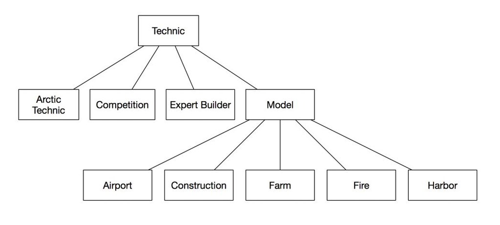

By joining a table to itself we can explore the relationship between themes and parents. By using the `parent_id` on the left to match the `id` column on the right, we end up with a table of child-parent relationships.

```r
themes %>%
  inner_join(themes, by = c("parent_id" = "id"),
             suffix = c("_child", "_parent"))
```

```
## # A tibble: 544 x 5
##       id name_child     parent_id name_parent parent_id_parent
##    <dbl> <chr>              <dbl> <chr>                  <dbl>
##  1     2 Arctic Technic         1 Technic                   NA
##  2     3 Competition            1 Technic                   NA
##  3     4 Expert Builder         1 Technic                   NA
##  4     5 Model                  1 Technic                   NA
##  5     6 Airport                5 Model                      1
##  6     7 Construction           5 Model                      1
##  7     8 Farm                   5 Model                      1
##  8     9 Fire                   5 Model                      1
##  9    10 Harbor                 5 Model                      1
## 10    11 Off-Road               5 Model                      1
## # ... with 534 more rows
```

Examine other LEGO sets that are themed around the fantasy series “The Lords of the Rings”.

```r
themes %>%
  inner_join(themes, by = c("parent_id" = "id"),
             suffix = c("_child", "_parent")) %>%
  filter(name_child == "The Lord of the Rings")
```

```
## # A tibble: 1 x 5
##      id name_child         parent_id name_parent                parent_id_parent
##   <dbl> <chr>                  <dbl> <chr>                                 <dbl>
## 1   566 The Lord of the R~       561 The Hobbit and Lord of th~               NA
```

Find out all of the children of that theme:

```r
themes %>%
  inner_join(themes, by = c("parent_id" = "id"),
             suffix = c("_child", "_parent")) %>%
  filter(name_parent == "The Lord of the Rings")
```

```
## # A tibble: 3 x 5
##      id name_child                parent_id name_parent         parent_id_parent
##   <dbl> <chr>                         <dbl> <chr>                          <dbl>
## 1   567 The Fellowship of the Ri~       566 The Lord of the Ri~              561
## 2   568 The Two Towers                  566 The Lord of the Ri~              561
## 3   569 The Return of the King          566 The Lord of the Ri~              561
```

Based on all this, we start understanding the shape of the data.

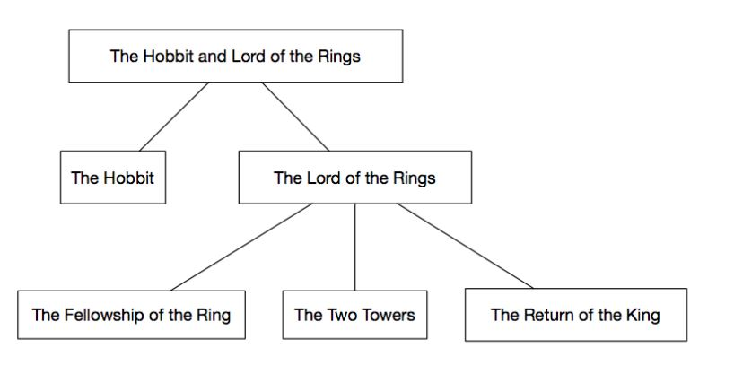

Discover what children of the “Harry Potter” theme are:

```r
themes %>%
  inner_join(themes, by = c("parent_id" = "id"),
             suffix = c("_child", "_parent")) %>%
  filter(name_parent == "Harry Potter")
```

```
## # A tibble: 6 x 5
##      id name_child           parent_id name_parent  parent_id_parent
##   <dbl> <chr>                    <dbl> <chr>                   <dbl>
## 1   247 Chamber of Secrets         246 Harry Potter               NA
## 2   248 Goblet of Fire             246 Harry Potter               NA
## 3   249 Order of the Phoenix       246 Harry Potter               NA
## 4   250 Prisoner of Azkaban        246 Harry Potter               NA
## 5   251 Sorcerer's Stone           246 Harry Potter               NA
## 6   667 Fantastic Beasts           246 Harry Potter               NA
```

Some themes might not have any children at all, which means they will not be included in the inner join. Left join a table to itself:

```r
themes %>%
  left_join(themes, by = c("id" = "parent_id"), suffix = c("_parent", "_child")) %>%
  filter(is.na(id_child) == TRUE)
```

```
## # A tibble: 586 x 5
##       id name_parent    parent_id id_child name_child
##    <dbl> <chr>              <dbl>    <dbl> <chr>
##  1     2 Arctic Technic         1       NA <NA>
##  2     3 Competition            1       NA <NA>
##  3     4 Expert Builder         1       NA <NA>
##  4     6 Airport                5       NA <NA>
##  5     7 Construction           5       NA <NA>
##  6     8 Farm                   5       NA <NA>
##  7     9 Fire                   5       NA <NA>
##  8    10 Harbor                 5       NA <NA>
##  9    11 Off-Road               5       NA <NA>
## 10    12 Race                   5       NA <NA>
## # ... with 576 more rows
```

From this table, we learned that there are 586 themes in total that do not have any child themes.

Go one step further by inner joining **themes** to a filtered version of itself again to establish a connection between the last join’s children and their children (or parents’ grandchildren):

```r
themes %>%
  inner_join(themes, by = c("id" = "parent_id"),
             suffix = c("_parent", "_child")) %>%
  inner_join(themes, by = c("id_child" = "parent_id"),
             suffix = c("_parent", "_grandchild"))
```

```
## # A tibble: 158 x 7
##    id_parent name_parent parent_id id_child name_child id_grandchild name
##        <dbl> <chr>           <dbl>    <dbl> <chr>              <dbl> <chr>
##  1         1 Technic            NA        5 Model                  6 Airport
##  2         1 Technic            NA        5 Model                  7 Constructi~
##  3         1 Technic            NA        5 Model                  8 Farm
##  4         1 Technic            NA        5 Model                  9 Fire
##  5         1 Technic            NA        5 Model                 10 Harbor
##  6         1 Technic            NA        5 Model                 11 Off-Road
##  7         1 Technic            NA        5 Model                 12 Race
##  8         1 Technic            NA        5 Model                 13 Riding Cyc~
##  9         1 Technic            NA        5 Model                 14 Robot
## 10         1 Technic            NA        5 Model                 15 Traffic
## # ... with 148 more rows
```